# Numerical Root Finding

## 1. The General Philosophy of Root Finding

At its most fundamental level, root finding is the quest to find a vector $\mathbf{x}^*$ such that:

$$ \mathbf{F}(\mathbf{x}^*) = \mathbf{0} $$

where $\mathbf{F}: \mathbb{R}^n \to \mathbb{R}^n$ is a continuous function.

The underlying philosophy is that analytical solutions to such equations are exceptionally rare. Therefore, we must rely on **iterative numerical methods**. We start with an initial guess $\mathbf{x}_0$ and generate a sequence $\{\mathbf{x}_k\}$ that, ideally, converges to $\mathbf{x}^*$.

Root-finding algorithms exist on a spectrum defined by a fundamental trade-off: **Robustness vs. Speed**.

- **Bracketing Methods:** Rely on the topological properties of the function (e.g., the Intermediate Value Theorem). They are slow but practically infallible.
- **Open Methods:** Rely on local geometric properties (derivatives, secant lines) to extrapolate a new guess. They are blindingly fast but can easily diverge if the initial guess is poor or the function's landscape is pathological.

We characterize speed by the **order of convergence**, $p$. If $\epsilon_k = x_k - x^*$ is the error at step $k$, then an algorithm has order $p$ if:

$$ \lim_{k \to \infty} \frac{|\epsilon_{k+1}|}{|\epsilon_k|^p} = C > 0 $$

where $C$ is the asymptotic error constant.

## 2. One-Dimensional vs. Multi-Dimensional Root Finding

The transition from $f(x) = 0$ (1D) to $\mathbf{F}(\mathbf{x}) = \mathbf{0}$ ($n$-D) represents a massive leap in mathematical complexity.

### What becomes a *little* harder?

**Function Evaluation and Local Geometry.** In 1D, finding the "slope" requires a single scalar derivative $f'(x)$. In $n$ dimensions, we must construct the Jacobian matrix $J(\mathbf{x})$, a matrix of $n^2$ partial derivatives. Updating our guess requires solving an $n \times n$ linear system rather than a simple scalar division. This increases computational cost ($O(n^3)$ per step), but the underlying linear algebraic mechanisms are well-understood.

### What becomes *much* harder?

**Bracketing and Global Convergence.** This is the true curse of dimensionality in root finding. In 1D, if we find two points $a$ and $b$ such that $f(a) \cdot f(b) < 0$, the Intermediate Value Theorem guarantees a root lies in $[a, b]$. We have effectively "trapped" the root.

In $n$-dimensions, there is no analogue to this sign change. A root is the intersection of $n$ different $(n-1)$-dimensional zero-contour hypersurfaces. You cannot simply evaluate the function at a few boundary points to guarantee a root exists within a volume. Because multidimensional bracketing is impossible, we must rely almost exclusively on "open" methods, making multi-dimensional root finding notoriously sensitive to the initial guess.

## 3. Bracketing and Linear Interpolation

### 3.1 The Midpoint Method (Bisection)

The most robust method relies purely on topology. Given a continuous function $f(x)$ and an initial interval $[a_0, b_0]$ such that $f(a_0)f(b_0) < 0$:

**The Update:**

$$ c_k = \frac{a_k + b_k}{2} $$

We evaluate $f(c_k)$. If $f(a_k)f(c_k) < 0$, the root is in the left half, so $b_{k+1} = c_k$ and $a_{k+1} = a_k$. Otherwise, the root is in the right half, so $a_{k+1} = c_k$ and $b_{k+1} = b_k$.

**Convergence:** At each step, the uncertainty in the root's location is exactly halved.

$$ |\epsilon_{k+1}| \le \frac{1}{2} |\epsilon_k| $$

This means $\lim_{k \to \infty} \frac{|\epsilon_{k+1}|}{|\epsilon_k|} = 0.5$. This is **Linear Convergence** ($p=1$). It is slow, gaining roughly one decimal digit of precision every 3.3 iterations ($\log_{10} 2 \approx 0.3$), but it absolutely cannot fail if the initial bracket is valid.

### 3.2 Secant and False-Position Methods

Instead of blindly cutting the interval in half, we can interpolate. We assume the function is approximately linear between our two current points, $(x_0, f(x_0))$ and $(x_1, f(x_1))$. The equation of this secant line is:

$$ y - f(x_1) = \frac{f(x_1) - f(x_0)}{x_1 - x_0} (x - x_1) $$

Setting $y=0$ to find where this line crosses the x-axis gives our update.

**The Update:**

$$ x_{k+1} = x_k - f(x_k) \frac{x_k - x_{k-1}}{f(x_k) - f(x_{k-1})} $$

**The Secant Method:** We blindly apply this formula using the two most recently computed points, discarding older ones. It is an *open* method (no bracket guaranteed).

- **Convergence:** The error obeys $|\epsilon_{k+1}| \approx C |\epsilon_k| |\epsilon_{k-1}|$. Through a fascinating connection to the Fibonacci sequence, this leads to an order of convergence equal to the Golden Ratio: $p = \frac{1+\sqrt{5}}{2} \approx 1.618$ **(Superlinear).**

**The False-Position Method (Regula Falsi):** We use the same secant formula, but we *enforce* bracketing. Out of $x_{k+1}$, $x_k$, and $x_{k-1}$, we keep the two points that bracket the root.

- **Convergence:** While guaranteed to converge, if the function is convex near the root, one endpoint will get "stuck," and the method degrades to abysmal **Linear Convergence** ($p=1$), often performing worse than bisection!

## 4. Advanced 1D Algorithms

### 4.1 Ridders' Method (A Variant of False Position)

C.J.F. Ridders (1979) devised an incredibly elegant solution to the False-Position endpoint-sticking problem. If $f(x)$ is highly non-linear, drawing a line through it is a bad approximation. Ridders proposed multiplying $f(x)$ by an exponential factor to "straighten it out," and then applying False-Position to the straightened function.

**Derivation:** Let $x_1$ and $x_2$ bracket the root. We evaluate the midpoint $x_3 = (x_1+x_2)/2$. We now have $f_1, f_2$, and $f_3$. Consider a new function: $h(x) = f(x)e^{Qx}$. We want to choose $Q$ such that $h(x_1)$, $h(x_3)$, and $h(x_2)$ lie on a straight line. Because $x_3$ is exactly halfway between $x_1$ and $x_2$, a straight line implies:

$$ h(x_3) - h(x_1) = h(x_2) - h(x_3) \implies 2h(x_3) = h(x_1) + h(x_2) $$

Substituting $h(x)$:

$$ 2f_3 e^{Qx_3} = f_1 e^{Qx_1} + f_2 e^{Qx_2} $$

Divide the entire equation by $e^{Qx_3}$ and let $W = e^{Q(x_3 - x_1)} = e^{Q(x_2 - x_3)}$:

$$ 2f_3 = f_1 W^{-1} + f_2 W \implies f_2 W^2 - 2f_3 W + f_1 = 0 $$

This is a quadratic in $W$. Solving for $W$ (and noting that $f_1$ and $f_2$ have opposite signs because they form a bracket, ensuring real roots):

Once $Q$ (and thus $h(x)$) is defined, we apply the standard False-Position formula to $h(x)$ using points $x_3$ and $x_1$ (or $x_2$). Because $h(x)$ is exactly linear across these three points, the mathematics collapses beautifully into a closed-form update.

**The Update:**

$$ x_4 = x_3 + (x_3 - x_1) \frac{\text{sgn}(f_1 - f_2) f_3}{\sqrt{f_3^2 - f_1 f_2}} $$

**Convergence:** Ridders' method is incredibly robust. By evaluating two points per step ($x_3$ and $x_4$), its effective order of convergence is $p = \sqrt{2} \approx 1.414$.

### 4.2 Brent's Method

Brent's method is both efficient and reliable. It is the gold standard for 1D root finding.

**The Algorithm Logic:** Brent's method dynamically chooses between three different techniques at every single iteration:

1. **Inverse Quadratic Interpolation (IQI):** If we have three distinct points $(x_1, y_1), (x_2, y_2), (x_3, y_3)$, we fit a sideways parabola $x = P(y)$ through them. We evaluate $P(0)$ to find the next guess:

   $$ x_{new} = \frac{y_2 y_3}{(y_1-y_2)(y_1-y_3)}x_1 + \frac{y_1 y_3}{(y_2-y_1)(y_2-y_3)}x_2 + \frac{y_1 y_2}{(y_3-y_1)(y_3-y_2)}x_3 $$
2. **Secant Method:** If we only have two distinct y-values, it attempts a standard Secant step.
3. **Bisection:** This is the fallback. Brent's algorithm monitors the step size. If the step proposed by IQI or Secant falls outside the current bounding bracket, OR if it isn't reducing the bracket size fast enough (e.g., the step is smaller than a predetermined tolerance), the algorithm instantly aborts the open method and forces a Bisection step.

**Convergence:** Guaranteed convergence (worst-case is equivalent to bisection). Near a well-behaved root, it behaves like IQI, achieving **Superlinear convergence with** $p \approx 1.839$.

## 5. Derivative-Based Methods

### 5.1 The Newton-Raphson Method

Newton's method is the crown jewel of root finding. It assumes we can evaluate both $f(x)$ and its analytical derivative $f'(x)$.

**Derivation via Taylor Expansion:** Suppose $x_k$ is our current guess. We expand $f(x)$ in a Taylor series around $x_k$:

$$ f(x) = f(x_k) + f'(x_k)(x - x_k) + \frac{1}{2}f''(c)(x - x_k)^2 + \dots $$

We want to find the root $x$ where $f(x) = 0$. By truncating the series after the linear term (assuming we are close enough to the root that squared terms are negligible), we approximate:

$$ 0 \approx f(x_k) + f'(x_k)(x - x_k) $$

Solving for $x$ yields our next iterative guess, $x_{k+1}$.

**The Update:**

$$ x_{k+1} = x_k - \frac{f(x_k)}{f'(x_k)} $$

**Why is it so powerful? Proof of Quadratic Convergence:** Let the true root be $x^*$. The error at step $k$ is $\epsilon_k = x_k - x^*$. We evaluate the exact Taylor expansion of $f(x^*)$ around $x_k$:

$$ 0 = f(x^*) = f(x_k) + f'(x_k)(x^* - x_k) + \frac{1}{2}f''(c)(x^* - x_k)^2 $$

Note that $x^* - x_k = -\epsilon_k$.

$$ 0 = f(x_k) - f'(x_k)\epsilon_k + \frac{1}{2}f''(c)\epsilon_k^2 $$

Divide the entire equation by $f'(x_k)$:

$$ 0 = \frac{f(x_k)}{f'(x_k)} - \epsilon_k + \frac{f''(c)}{2f'(x_k)}\epsilon_k^2 $$

Now, look at our update formula, subtract $x^*$ from both sides:

$$ x_{k+1} - x^* = x_k - x^* - \frac{f(x_k)}{f'(x_k)} \implies \epsilon_{k+1} = \epsilon_k - \frac{f(x_k)}{f'(x_k)} $$

Substituting this into our Taylor equation yields:

$$ 0 = - \epsilon_{k+1} + \frac{f''(c)}{2f'(x_k)}\epsilon_k^2 \implies \epsilon_{k+1} = \left( \frac{f''(c)}{2f'(x_k)} \right) \epsilon_k^2 $$

Because $\epsilon_{k+1} \propto \epsilon_k^2$, Newton's method exhibits **Quadratic Convergence (**$p=2$**)**. *Practical Meaning:* The number of correct decimal places literally doubles with every single iteration! If you have 3 correct digits, the next step gives you 6, then 12, then 24.

### 5.2 Newton's Method for Nonlinear Systems

The elegance of Newton's method is that its Taylor-series derivation translates seamlessly to $n$ dimensions. We are solving $\mathbf{F}(\mathbf{x}) = \mathbf{0}$.

**Derivation:** We expand the vector function $\mathbf{F}$ in a multidimensional Taylor series around $\mathbf{x}_k$:

$$ \mathbf{F}(\mathbf{x}_k + \Delta\mathbf{x}) \approx \mathbf{F}(\mathbf{x}_k) + J(\mathbf{x}_k)\Delta\mathbf{x} $$

where $J(\mathbf{x})$ is the Jacobian matrix, defined as $J_{ij} = \frac{\partial F_i}{\partial x_j}$. Setting the left side to the zero vector, we solve for the step $\Delta\mathbf{x}$:

$$ J(\mathbf{x}_k)\Delta\mathbf{x} = -\mathbf{F}(\mathbf{x}_k) $$

**The Update:**

$$ \mathbf{x}_{k+1} = \mathbf{x}_k + \Delta\mathbf{x} \quad \text{where} \quad \Delta\mathbf{x} = -J^{-1}(\mathbf{x}_k)\mathbf{F}(\mathbf{x}_k) $$

*(Note: In computation, we never invert the Jacobian matrix explicitly; we solve the linear system* $J \Delta\mathbf{x} = -\mathbf{F}$ *using techniques like LU Decomposition.)*

**Convergence:** Retains **Quadratic Convergence (**$p=2$**)**, but it is highly unstable if the initial guess $\mathbf{x}_0$ is not sufficiently close to the true root $\mathbf{x}^*$.

```python
import math
import numpy as np
import matplotlib.pyplot as plt
```

```python
def midpoint_method(f, a, b, tol=1e-12, max_iter=200):
    """
    Standard Bisection (Midpoint) Method.
    """
    fa, fb = f(a), f(b)
    if fa * fb >= 0:
        raise ValueError(
            "Initial bracket is invalid: f(a) and f(b) must have opposite signs."
        )

    evals = 2
    for i in range(max_iter):
        c = (a + b) / 2.0
        fc = f(c)
        evals += 1

        # Stop condition: bracket is small enough or we hit the root exactly
        if abs(fc) < tol or (b - a) / 2.0 < tol:
            return c, i + 1, evals

        if fa * fc < 0:
            b = c
            fb = fc
        else:
            a = c
            fa = fc

    return c, max_iter, evals
```

```python
def false_position_method(f, a, b, tol=1e-12, max_iter=200):
    """
    False-Position (Regula Falsi) Method.
    """
    fa, fb = f(a), f(b)
    if fa * fb >= 0:
        raise ValueError(
            "Initial bracket is invalid: f(a) and f(b) must have opposite signs."
        )

    evals = 2
    c = a
    for i in range(max_iter):
        c_old = c
        # Secant interpolation formula
        c = a - fa * (b - a) / (fb - fa)
        fc = f(c)
        evals += 1

        # Stop condition: function value is small or change in c is negligible
        if abs(fc) < tol or abs(c - c_old) < tol:
            return c, i + 1, evals

        # Update bracket to maintain opposite signs
        if fa * fc < 0:
            b = c
            fb = fc
        else:
            a = c
            fa = fc

    return c, max_iter, evals
```

```python
def ridders_method(f, a, b, tol=1e-12, max_iter=200):
    """
    Ridders' Method.
    Evaluates midpoint, introduces an exponential factor to "straighten" the curve,
    and reliably guarantees superlinear convergence without endpoint sticking.
    """
    fa, fb = f(a), f(b)
    if fa * fb >= 0:
        raise ValueError(
            "Initial bracket is invalid: f(a) and f(b) must have opposite signs."
        )

    evals = 2
    d_old = a
    for i in range(max_iter):
        # 1. Evaluate midpoint
        c = (a + b) / 2.0
        fc = f(c)
        evals += 1

        # 2. Calculate straightening factor denominator
        s = math.sqrt(fc**2 - fa * fb)
        if s == 0:
            return c, i + 1, evals

        # 3. Calculate Ridders' updated root guess (d)
        sign = 1.0 if (fa - fb) > 0 else -1.0
        d = c + (c - a) * sign * fc / s
        fd = f(d)
        evals += 1

        # Stop condition
        if abs(fd) < tol or abs(d - d_old) < tol:
            return d, i + 1, evals

        d_old = d

        # 4. Smart Re-bracketing
        # The root is guaranteed to be between c and d if their function values have opposite signs
        if fc * fd < 0:
            a, fa = c, fc
            b, fb = d, fd
        elif fa * fd < 0:
            b, fb = d, fd
        else:
            a, fa = d, fd

    return d_old, max_iter, evals
```

```python
def brents_method(f, a, b, tol=1e-12, max_iter=200):
    """
    Brent's Method.
    Combines Bisection, Secant, and Inverse Quadratic Interpolation.
    Extremely robust and usually superlinear. The industry standard.
    """
    fa, fb = f(a), f(b)
    if fa * fb >= 0:
        raise ValueError("Initial bracket is invalid: f(a) and f(b) must have opposite signs.")

    if abs(fa) < abs(fb):
        a, b = b, a
        fa, fb = fb, fa

    c = a
    fc = fa
    mflag = True
    evals = 2
    d = 0.0 # Will hold the 'old c' for convergence checks

    for i in range(max_iter):
        if abs(b - a) < tol or abs(fb) < tol:
            return b, i + 1, evals

        # 1. Choose interpolation method
        if fa != fc and fb != fc:
            # Inverse Quadratic Interpolation
            s = a * fb * fc / ((fa - fb) * (fa - fc)) + \
                b * fa * fc / ((fb - fa) * (fb - fc)) + \
                c * fa * fb / ((fc - fa) * (fc - fb))
        else:
            # Secant Method
            s = b - fb * (b - a) / (fb - fa)

        # 2. Check if we need to force bisection for safety
        cond1 = (s < (3 * a + b) / 4.0 and s < b) or (s > (3 * a + b) / 4.0 and s > b)
        cond2 = mflag and abs(s - b) >= abs(b - c) / 2.0
        cond3 = not mflag and abs(s - b) >= abs(c - d) / 2.0
        cond4 = mflag and abs(b - c) < tol
        cond5 = not mflag and abs(c - d) < tol

        if cond1 or cond2 or cond3 or cond4 or cond5:
            s = (a + b) / 2.0
            mflag = True
        else:
            mflag = False

        # 3. Evaluate new point
        fs = f(s)
        evals += 1
        d = c
        c = b
        fc = fb

        # 4. Re-bracket
        if fa * fs < 0:
            b = s
            fb = fs
        else:
            a = s
            fa = fs

        if abs(fa) < abs(fb):
            a, b = b, a
            fa, fb = fb, fa

    return b, max_iter, evals
```

```python
def newton_raphson_method(f, df, x0, tol=1e-12, max_iter=200):
    """
    Newton-Raphson Method.
    Requires the derivative of the function.
    Extremely fast (quadratic) if guess is good, but can diverge wildly.
    """
    x = x0
    evals = 0
    for i in range(max_iter):
        try:
            fx = f(x)
            dfx = df(x)
        except OverflowError:
            return float("inf"), i + 1, evals

        evals += 2

        if abs(fx) < tol:
            return x, i + 1, evals

        if dfx == 0:
            return float("inf"), max_iter, evals  # Failed (division by zero)

        x = x - fx / dfx

        # Prevent runaway divergence for clean output
        if abs(x) > 1e20:
            return float("inf"), i + 1, evals

    return x, max_iter, evals
```

```python
def plot_problem_with_fp_steps(p):
    """
    Plots the function and visually demonstrates the first few steps
    of the False-Position method to highlight how it converges (or gets stuck).
    """
    f = p["func"]
    a, b = p["bracket"]

    # Generate x values slightly beyond the bracket for context
    x_vals = np.linspace(a - 0.1 * (b - a), b + 0.1 * (b - a), 500)
    y_vals = [f(xi) for xi in x_vals]

    plt.figure(figsize=(9, 6))
    plt.plot(x_vals, y_vals, label="f(x)", color="#1f77b4", linewidth=2)
    plt.axhline(0, color="black", linewidth=1, linestyle="--")

    # Plot initial bracket
    plt.plot(a, f(a), "ro", label=f"Initial a={a}")
    plt.plot(b, f(b), "go", label=f"Initial b={b}")

    # Simulate first few FP steps to plot secant lines
    curr_a, curr_b = a, b
    fa, fb = f(curr_a), f(curr_b)

    colors = ["orange", "purple", "cyan", "magenta"]
    for i in range(4):
        c = curr_a - fa * (curr_b - curr_a) / (fb - fa)
        fc = f(c)

        # Plot secant line and the new root guess
        plt.plot(
            [curr_a, curr_b],
            [fa, fb],
            color=colors[i],
            linestyle=":",
            linewidth=1.5,
            label=f"FP Secant {i+1}",
        )
        plt.plot(c, 0, marker="x", color=colors[i], markersize=8)
        plt.vlines(c, 0, fc, color=colors[i], linestyle=":", alpha=0.5)

        if fa * fc < 0:
            curr_b, fb = c, fc
        else:
            curr_a, fa = c, fc

    # Annotate the specific issue for the highly convex problem
    if "stuck" in p["name"].lower():
        plt.annotate(
            "FP gets stuck!\nThe right endpoint 'b' remains anchored high up.\nSecant lines pivot around it, causing 'a' \nto creep rightward agonizingly slowly.",
            xy=(0.1, 5),
            xytext=(0.1, 30),
            arrowprops=dict(facecolor="black", shrink=0.05, width=1.5, headwidth=8),
            fontsize=10,
            bbox=dict(boxstyle="round", fc="white", ec="red", alpha=0.9),
        )

    if "diverge" in p["name"].lower():
        plt.annotate(
            "Newton Diverges!\nTangents shoot the guess outward\ninto the flat asymptotes.",
            xy=(2.0, math.atan(2.0)),
            xytext=(-2.5, 1.0),
            arrowprops=dict(facecolor="black", shrink=0.05, width=1.5, headwidth=8),
            fontsize=10,
            bbox=dict(boxstyle="round", fc="white", ec="purple", alpha=0.9),
        )

    plt.title(f"{p['name']}\nFalse-Position Method Visualization")
    plt.xlabel("x")
    plt.ylabel("f(x)")
    plt.grid(True, alpha=0.3)
    plt.legend()
    plt.tight_layout()
    plt.show(block=False)
```

```
-----------------------------------------------------------------
Problem: Exponential Root: f(x) = e^x - 2
Bracket: [0.0, 2.0]
-----------------------------------------------------------------
Method             | Root Found      | Iters  | Evals
-----------------------------------------------------------------
Midpoint (Bisect)  | 0.69314718056   | 40     | 42
False-Position     | 0.69314718056   | 42     | 44
Ridders'           | 0.69314718056   | 4      | 10
Brent's            | 0.69314718056   | 8      | 9
Newton-Raphson     | 0.69314718056     | 7      | 14
```

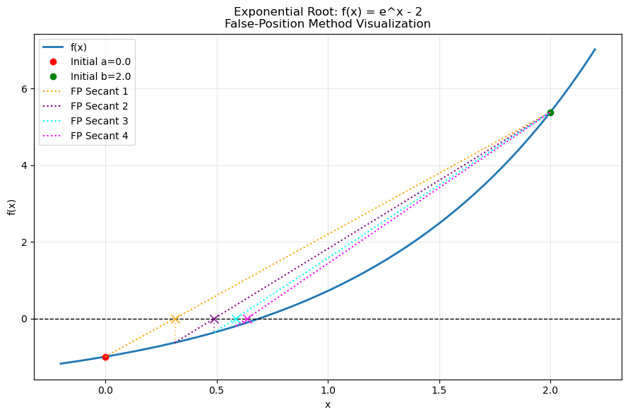

```
-----------------------------------------------------------------
Problem: Cubic Polynomial: f(x) = x^3 - 2x - 5
Bracket: [2.0, 3.0]
-----------------------------------------------------------------
Method             | Root Found      | Iters  | Evals
-----------------------------------------------------------------
Midpoint (Bisect)  | 2.09455148154   | 40     | 42
False-Position     | 2.09455148154   | 26     | 28
Ridders'           | 2.09455148154   | 5      | 12
Brent's            | 2.09455148154   | 6      | 7
Newton-Raphson     | 2.09455148154     | 6      | 12
```

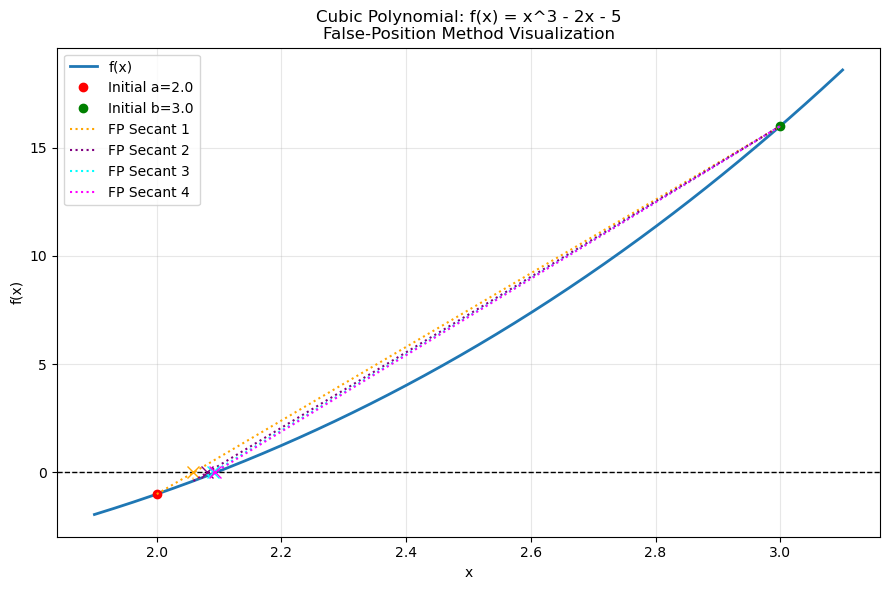

```
-----------------------------------------------------------------
Problem: Trig Intersection: f(x) = sin(x) - x/2
Bracket: [1.5, 2.5]
-----------------------------------------------------------------
Method             | Root Found      | Iters  | Evals
-----------------------------------------------------------------
Midpoint (Bisect)  | 1.89549426703   | 39     | 41
False-Position     | 1.89549426703   | 19     | 21
Ridders'           | 1.89549426703   | 4      | 10
Brent's            | 1.89549426703   | 7      | 8
Newton-Raphson     | 1.89549426703     | 6      | 12
```

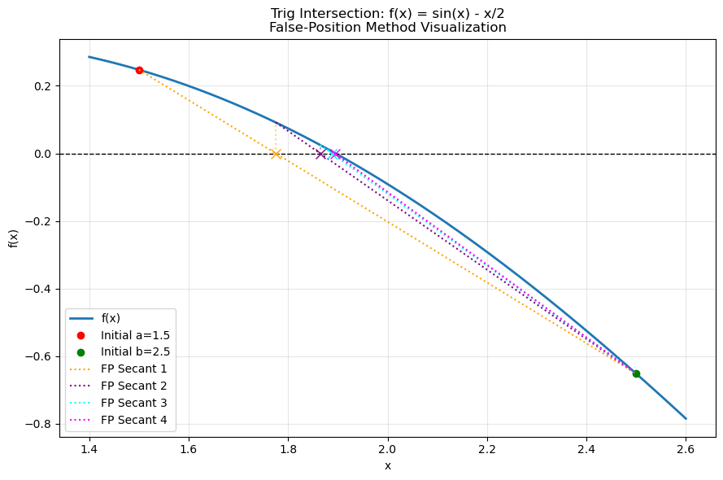

```
-----------------------------------------------------------------
Problem: High Convexity (FP stuck): f(x) = x^10 - 1
Bracket: [0.0, 1.5]
-----------------------------------------------------------------
Method             | Root Found      | Iters  | Evals
-----------------------------------------------------------------
Midpoint (Bisect)  | 1.00000000000   | 41     | 43
False-Position     | 0.99999978899   | 200    | 202
Ridders'           | 1.00000000000   | 5      | 12
Brent's            | 1.00000000000   | 11     | 12
Newton-Raphson     | 1.00000000000     | 10     | 20
```

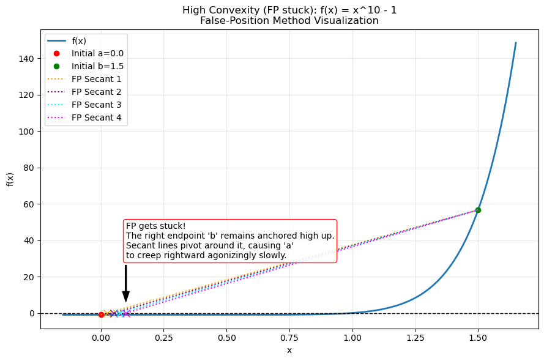

```
-----------------------------------------------------------------
Problem: Newton Shines: f(x) = x^2 - 2
Bracket: [1.0, 2.0]
-----------------------------------------------------------------
Method             | Root Found      | Iters  | Evals
-----------------------------------------------------------------
Midpoint (Bisect)  | 1.41421356237   | 38     | 40
False-Position     | 1.41421356237   | 16     | 18
Ridders'           | 1.41421356237   | 4      | 10
Brent's            | 1.41421356237   | 6      | 7
Newton-Raphson     | 1.41421356237     | 6      | 12
```

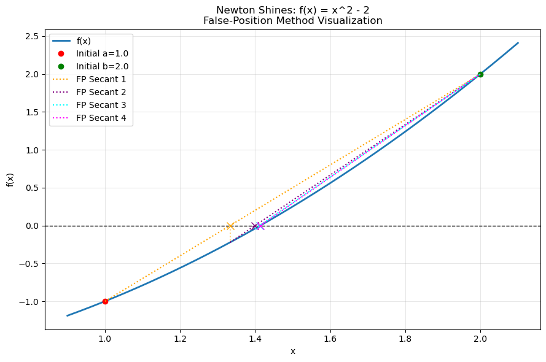

```
-----------------------------------------------------------------
Problem: Newton Diverges: f(x) = arctan(x)
Bracket: [-3.0, 4.0]
-----------------------------------------------------------------
Method             | Root Found      | Iters  | Evals
-----------------------------------------------------------------
Midpoint (Bisect)  | 0.00000000000   | 40     | 42
False-Position     | 0.00000000000   | 5      | 7
Ridders'           | 0.00000000000   | 5      | 12
Brent's            | 0.00000000000   | 6      | 7
Newton-Raphson     | DIVERGED/FAILED   | 6      | 12
```

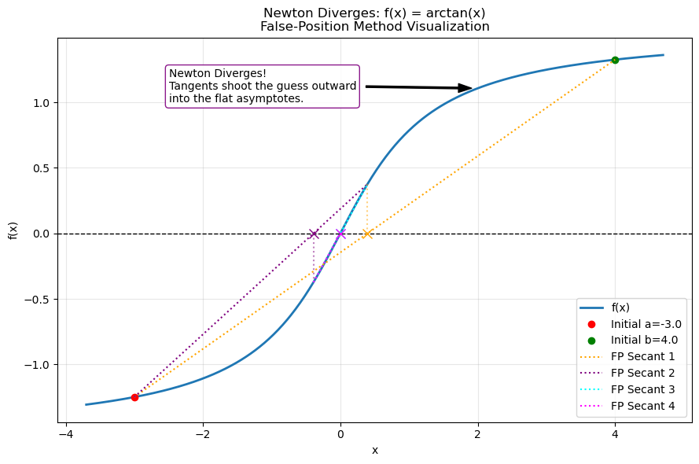

```python
# =====================================================================
# TEST PROBLEMS
# We choose 3 functions where the curvature is relatively benign.
# This prevents False-Position from getting heavily stuck, allowing
# it to beat Bisection, while letting Ridders' method truly shine.
# =====================================================================


def run_comparisons():
    problems = [
        {
            "name": "Exponential Root: f(x) = e^x - 2",
            "func": lambda x: math.exp(x) - 2.0,
            "dfunc": lambda x: math.exp(x),
            "bracket": (0.0, 2.0),
            "x0": 2.0,
            "expected_root": math.log(2),
        },
        {
            "name": "Cubic Polynomial: f(x) = x^3 - 2x - 5",
            "func": lambda x: x**3 - 2 * x - 5.0,
            "dfunc": lambda x: 3 * x**2 - 2.0,
            "bracket": (2.0, 3.0),
            "x0": 3.0,
            "expected_root": 2.094551481542,
        },
        {
            "name": "Trig Intersection: f(x) = sin(x) - x/2",
            "func": lambda x: math.sin(x) - x / 2.0,
            "dfunc": lambda x: math.cos(x) - 0.5,
            "bracket": (1.5, 2.5),
            "x0": 1.5,
            "expected_root": 1.895494267034,
        },
        {
            "name": "High Convexity (FP stuck): f(x) = x^10 - 1",
            "func": lambda x: x**10 - 1.0,
            "dfunc": lambda x: 10 * x**9,
            "bracket": (0.0, 1.5),
            "x0": 1.5,
            "expected_root": 1.0,
        },
        {
            "name": "Newton Shines: f(x) = x^2 - 2",
            "func": lambda x: x**2 - 2.0,
            "dfunc": lambda x: 2 * x,
            "bracket": (1.0, 2.0),
            "x0": 2.0,
            "expected_root": math.sqrt(2),
        },
        {
            "name": "Newton Diverges: f(x) = arctan(x)",
            "func": lambda x: math.atan(x),
            "dfunc": lambda x: 1.0 / (1.0 + x**2),
            "bracket": (-3.0, 4.0),
            "x0": 3.0,
            "expected_root": 0.0,
        },
    ]

    for p in problems:
        print(f"\n{'-'*65}")
        print(f"Problem: {p['name']}")
        print(f"Bracket: [{p['bracket'][0]}, {p['bracket'][1]}]")
        print(f"{'-'*65}")
        print(f"{'Method':<18} | {'Root Found':<15} | {'Iters':<6} | {'Evals':<6}")
        print(f"{'-'*65}")

        f = p["func"]
        a, b = p["bracket"]

        # 1. Midpoint (Bisection)
        root_m, iters_m, evals_m = midpoint_method(f, a, b)
        print(
            f"{'Midpoint (Bisect)':<18} | {root_m:<15.11f} | {iters_m:<6} | {evals_m:<6}"
        )

        # 2. False-Position
        root_fp, iters_fp, evals_fp = false_position_method(f, a, b)
        print(
            f"{'False-Position':<18} | {root_fp:<15.11f} | {iters_fp:<6} | {evals_fp:<6}"
        )

        # 3. Ridders' Method
        root_r, iters_r, evals_r = ridders_method(f, a, b)
        ridders_name = "Ridders'"
        print(f"{ridders_name:<18} | {root_r:<15.11f} | {iters_r:<6} | {evals_r:<6}")

        # 4. Brent's Method
        root_b, iters_b, evals_b = brents_method(f, a, b)
        brents_name = "Brent's"
        print(f"{brents_name:<18} | {root_b:<15.11f} | {iters_b:<6} | {evals_b:<6}")

        # 5. Newton-Raphson Method
        df = p["dfunc"]
        x0 = p["x0"]
        root_n, iters_n, evals_n = newton_raphson_method(f, df, x0)

        if iters_n == 200 or root_n == float("inf") or math.isnan(root_n):
            print(
                f"{'Newton-Raphson':<18} | {'DIVERGED/FAILED':<17} | {iters_n:<6} | {evals_n:<6}"
            )
        else:
            print(
                f"{'Newton-Raphson':<18} | {root_n:<17.11f} | {iters_n:<6} | {evals_n:<6}"
            )

        # Plot the problem to visualize FP behavior
        plot_problem_with_fp_steps(p)

    print(f"\n{'-'*65}")
    plt.show()  # Block at the end until user closes all plots


run_comparisons()
```

```
Path for x0=0.600: ['0.6000', '5.4000', '3.6416', '2.4903', '1.7545', '1.3117', '1.0846', '1.0090', '1.0001', '1.0000', '1.0000']
Path for x0=0.450: ['0.4500', '-0.4643', '0.5669', '-10.1564', '-6.7929', '-4.5615', '-3.0905', '-2.1349', '-1.5355', '-1.1922', '-1.0383', '-1.0020', '-1.0000', '-1.0000', '-1.0000']
Path for x0=0.577: ['0.5774']
Path for x0=-0.100: ['-0.1000', '0.0021', '-0.0000', '0.0000']
```

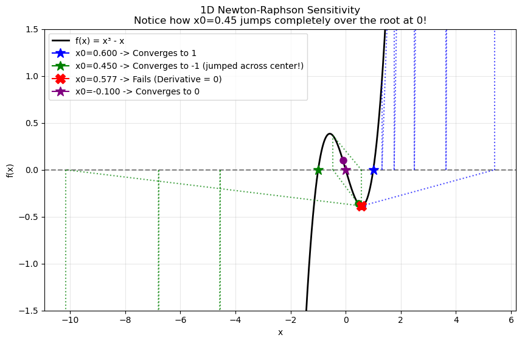

```python
# =====================================================================
# 1D NEWTON-RAPHSON SENSITIVITY
# =====================================================================
def newton_1d(f, df, x0, tol=1e-6, max_iter=20):
    """1D Newton-Raphson that returns the path taken."""
    x_path = [x0]
    x = x0
    for _ in range(max_iter):
        dfx = df(x)
        if abs(dfx) < 1e-12:  # Derivative is zero, method fails
            break

        x_new = x - f(x) / dfx
        x_path.append(x_new)

        if abs(x_new - x) < tol:
            break
        x = x_new

    return x_path


def run_1d_demo():
    """
    Function: f(x) = x^3 - x
    Roots: x = -1, 0, 1
    Extrema (where f'(x)=0): x = +/- 1/sqrt(3) approx +/- 0.577
    """
    f = lambda x: x**3 - x
    df = lambda x: 3 * x**2 - 1.0

    # Generate plot
    x_vals = np.linspace(-1.5, 1.5, 500)
    plt.figure(figsize=(10, 6))
    plt.plot(x_vals, f(x_vals), "k-", linewidth=2, label="f(x) = x³ - x")
    plt.axhline(0, color="gray", linestyle="--")

    # Test different initial guesses
    guesses = [
        (0.60, "blue", "Converges to 1"),
        (0.45, "green", "Converges to -1 (jumped across center!)"),
        (1 / np.sqrt(3), "red", "Fails (Derivative = 0)"),
        (-0.10, "purple", "Converges to 0"),
    ]

    for x0, color, label in guesses:
        path = newton_1d(f, df, x0)
        print(f"Path for x0={x0:.3f}: {[f'{x:.4f}' for x in path]}")

        # Plot starting point
        plt.plot(path[0], f(path[0]), marker="o", color=color, markersize=8)

        # Plot trajectory if it didn't immediately fail
        if len(path) > 1:
            for i in range(min(len(path) - 1, 5)):  # Show first few steps
                x_curr, x_next = path[i], path[i + 1]
                # Tangent line step
                plt.plot(
                    [x_curr, x_next],
                    [f(x_curr), 0],
                    color=color,
                    linestyle=":",
                    alpha=0.7,
                )
                # Vertical line back to function
                if i < len(path) - 2:
                    plt.plot(
                        [x_next, x_next],
                        [0, f(x_next)],
                        color=color,
                        linestyle=":",
                        alpha=0.7,
                    )

            # Final root marker
            plt.plot(
                path[-1],
                0,
                marker="*",
                color=color,
                markersize=12,
                label=f"x0={x0:.3f} -> {label}",
            )
        else:
            plt.plot(
                path[0],
                f(path[0]),
                marker="X",
                color=color,
                markersize=12,
                label=f"x0={x0:.3f} -> {label}",
            )

    plt.title(
        "1D Newton-Raphson Sensitivity\nNotice how x0=0.45 jumps completely over the root at 0!"
    )
    plt.xlabel("x")
    plt.ylabel("f(x)")
    plt.ylim(-1.5, 1.5)
    plt.legend()
    plt.grid(True, alpha=0.3)
    plt.show()

run_1d_demo()
```

```
Computing 2D Newton Basins of Attraction...
Testing 90000 initial guesses. This may take a few seconds...
```

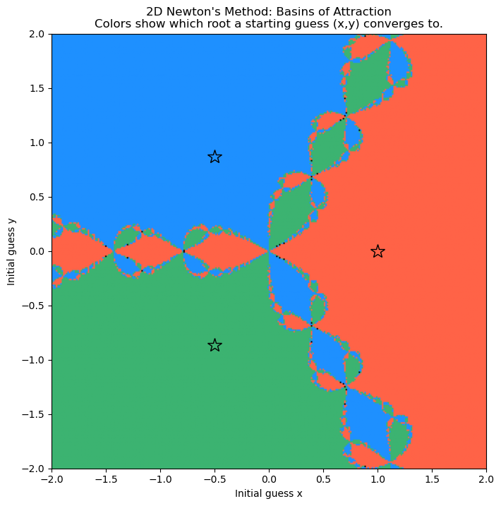

```python
# =====================================================================
# 2D NEWTON-RAPHSON SENSITIVITY (BASINS OF ATTRACTION)
# =====================================================================
def newton_2d(F, J, X0, tol=1e-5, max_iter=30):
    """
    2D Newton-Raphson.
    X0 is a numpy array [x, y].
    Returns the final coordinate (rounded) to identify which root was found.
    """
    X = X0.copy()
    for _ in range(max_iter):
        Fx = F(X)
        Jx = J(X)

        # Check for singular Jacobian (determinant = 0)
        if abs(np.linalg.det(Jx)) < 1e-12:
            return None

        # Update: X_new = X - J^-1 * F
        step = np.linalg.solve(Jx, Fx)
        X = X - step

        if np.linalg.norm(step) < tol:
            return np.round(X, 3)  # Rounding helps group the roots

    return None  # Did not converge


def run_2d_demo():
    """
    System of non-linear equations derived from z^3 - 1 = 0 in complex plane.
    F1(x, y) = x^3 - 3xy^2 - 1 = 0
    F2(x, y) = 3x^2y - y^3 = 0

    Roots are (1, 0), (-0.5, sqrt(3)/2), (-0.5, -sqrt(3)/2).
    """

    def F(X):
        x, y = X[0], X[1]
        return np.array([x**3 - 3 * x * y**2 - 1.0, 3 * x**2 * y - y**3])

    def J(X):
        x, y = X[0], X[1]
        return np.array(
            [
                [3 * x**2 - 3 * y**2, -6 * x * y],
                [6 * x * y, 3 * x**2 - 3 * y**2],
            ]
        )

    # Create a grid of initial guesses
    res = 300  # Resolution of the grid (300x300 points)
    x_range = np.linspace(-2, 2, res)
    y_range = np.linspace(-2, 2, res)

    # Image to store the root assignments (0, 1, or 2 for the three roots, -1 for fail)
    basin_image = np.zeros((res, res))

    # Define our known expected roots to classify them
    root_0 = np.array([1.0, 0.0])
    root_1 = np.array([-0.5, np.sqrt(3) / 2])
    root_2 = np.array([-0.5, -np.sqrt(3) / 2])

    print("Computing 2D Newton Basins of Attraction...")
    print(f"Testing {res*res} initial guesses. This may take a few seconds...")

    for i, x0 in enumerate(x_range):
        for j, y0 in enumerate(y_range):
            if x0 == 0 and y0 == 0:
                basin_image[j, i] = -1  # Jacobian is singular at origin
                continue

            X_init = np.array([x0, y0])
            root = newton_2d(F, J, X_init)

            if root is None:
                basin_image[j, i] = -1  # Diverged or singular
            else:
                # Classify which root it converged to
                if np.allclose(root, root_0, atol=1e-2):
                    basin_image[j, i] = 0
                elif np.allclose(root, root_1, atol=1e-2):
                    basin_image[j, i] = 1
                elif np.allclose(root, root_2, atol=1e-2):
                    basin_image[j, i] = 2
                else:
                    basin_image[j, i] = -1

    # Plot the fractal (Basins of Attraction)
    plt.figure(figsize=(8, 8))

    # Custom color map mapping roots to distinct colors
    from matplotlib.colors import ListedColormap

    cmap = ListedColormap(["black", "tomato", "dodgerblue", "mediumseagreen"])
    # black = fail/unknown, tomato = root_0, blue = root_1, green = root_2

    plt.imshow(basin_image, extent=(-2, 2, -2, 2), origin="lower", cmap=cmap)

    # Plot the actual roots as colored stars matching their basins
    plt.plot(
        root_0[0],
        root_0[1],
        marker="*",
        color="tomato",
        markersize=15,
        markeredgecolor="black",
        linestyle="None",
    )
    plt.plot(
        root_1[0],
        root_1[1],
        marker="*",
        color="dodgerblue",
        markersize=15,
        markeredgecolor="black",
        linestyle="None",
    )
    plt.plot(
        root_2[0],
        root_2[1],
        marker="*",
        color="mediumseagreen",
        markersize=15,
        markeredgecolor="black",
        linestyle="None",
    )

    plt.title(
        "2D Newton's Method: Basins of Attraction\nColors show which root a starting guess (x,y) converges to."
    )
    plt.xlabel("Initial guess x")
    plt.ylabel("Initial guess y")


run_2d_demo()
```

## 6. Polynomial Root Finding

Polynomials $P(x) = c_n x^n + \dots + c_1 x + c_0$ are special. They always have exactly $n$ roots in the complex plane (Fundamental Theorem of Algebra). specialized methods exist to exploit this structure.

### 6.1 Muller's Method

Muller's method is a generalization of the Secant method. While the Secant method fits a line through two points, Muller's method fits a parabola through three points. The magic of Muller's method is that a parabola can have complex roots even if the three points used to create it are strictly real. Thus, it can find complex roots without requiring complex initial guesses.

**Derivation:** Given three points $x_0, x_1, x_2$, we define a local quadratic $P(x) = a(x-x_2)^2 + b(x-x_2) + c$. By requiring $P(x_i) = f(x_i)$ for $i=0,1,2$, it is trivially true that $c = f(x_2)$. Using divided differences, we can solve for $a$ and $b$:

$$ a = \frac{ (x_1 - x_2)[f(x_0) - f(x_2)] - (x_0 - x_2)[f(x_1) - f(x_2)] }{ (x_0 - x_1)(x_0 - x_2)(x_1 - x_2) } $$

$$ b = \frac{ (x_0 - x_2)^2[f(x_1) - f(x_2)] - (x_1 - x_2)^2[f(x_0) - f(x_2)] }{ (x_0 - x_1)(x_0 - x_2)(x_1 - x_2) } $$

**The Update:** To find the root of this parabola, we set $P(x) = 0$:

$$ a(x-x_2)^2 + b(x-x_2) + c = 0 $$

We can treat the difference $(x-x_2)$ as our variable. Applying the standard quadratic formula yields the distance from our current point $x_2$ to the new root guess $x_3$:

$$ x_3 - x_2 = \frac{-b \pm \sqrt{b^2 - 4ac}}{2a} $$

However, to avoid catastrophic cancellation (loss of precision when subtracting similar numbers), Muller rewrote the quadratic formula by multiplying numerator and denominator by the conjugate:

$$ x_3 = x_2 - \frac{2c}{b \pm \sqrt{b^2 - 4ac}} $$

We choose the sign ($\pm$) that maximizes the absolute value of the denominator. This ensures we step to the root of the parabola that is *closest* to our current point $x_2$.

**Convergence:** Superlinear, with order $p \approx 1.84$.

### 6.2 Laguerre's Method for Complex Numbers

Laguerre's method is arguably the most powerful algorithm specifically designed for polynomials. It guarantees convergence to a root from *any* starting guess if all roots are real, but it is overwhelmingly the method of choice for finding complex roots as well.

**Derivation:** Let $P(x) = (x-r_1)(x-r_2)\dots(x-r_n)$. Define the logarithmic derivative $G(x)$:

$$ G(x) = \frac{P'(x)}{P(x)} = \sum_{i=1}^n \frac{1}{x-r_i} $$

Define the negative derivative of $G(x)$, called $H(x)$:

$$ H(x) = -\frac{dG}{dx} = \left(\frac{P'(x)}{P(x)}\right)^2 - \frac{P''(x)}{P(x)} = \sum_{i=1}^n \frac{1}{(x-r_i)^2} $$

Suppose we are at a guess $x$, looking for the root $r_1$. Let $a = x - r_1$ be the distance to the root we want. Now, we make a radical, simplifying assumption: Assume all the *other* $n-1$ roots are clustered together at an identical distance $b$ from $x$. Thus, $G(x)$ and $H(x)$ become:

$$ G = \frac{1}{a} + \frac{n-1}{b} \quad \text{and} \quad H = \frac{1}{a^2} + \frac{n-1}{b^2} $$

This is a system of two equations with two unknowns ($a$ and $b$). We eliminate $b$: From the first equation, $b = \frac{n-1}{G - 1/a}$. Substitute this into the second:

$$ H = \frac{1}{a^2} + \frac{(G - 1/a)^2}{n-1} $$

Multiply out and rearrange into a quadratic in terms of $a$:

$$ (n-1)H - G^2 = \frac{n}{a^2} - \frac{2G}{a} \implies [ (n-1)H - G^2 ]a^2 + 2Ga - n = 0 $$

**The Update:** Solving this quadratic for $a$, and recalling that $r_1= x - a \Rightarrow x_{next} = x - a$, gives Laguerre's formula:

$$ x_{k+1} = x_k - \frac{n}{G \pm \sqrt{(n-1)(nH - G^2)}} $$

Again, we choose the sign in the denominator to maximize its absolute value, ensuring the smallest possible step $a$.

**Convergence:** For simple roots, Laguerre's method exhibits **Cubic Convergence (**$p=3$**)**. It requires evaluating $P(x)$, $P'(x)$, and $P''(x)$ at each step, but the mathematical guarantee of rapid convergence, particularly jumping effortlessly into the complex plane (because the term inside the square root naturally becomes negative when complex roots are nearby), makes it unparalleled for polynomial equations.

```python
import cmath
import matplotlib.pyplot as plt
import numpy as np
```

```python
def muller_method(f, x0, x1, x2, tol=1e-12, max_iter=100):
    """
    Muller's Method.
    Fits a complex parabola through 3 points to find the next guess.
    Only requires evaluating the function f(x), no derivatives needed!
    """
    # Start with 3 evaluations for the initial guesses
    evals = 3

    for i in range(max_iter):
        f0, f1, f2 = f(x0), f(x1), f(x2)

        h1 = x1 - x0
        h2 = x2 - x1

        # Prevent division by zero if points converge prematurely
        if abs(h1) < 1e-14 or abs(h2) < 1e-14:
            return x2, i + 1, evals

        # First divided differences
        delta1 = (f1 - f0) / h1
        delta2 = (f2 - f1) / h2

        # Second divided difference (a), and coefficients b, c
        a = (delta2 - delta1) / (x2 - x0)
        b = delta2 + h2 * a
        c = f2

        rad = cmath.sqrt(b**2 - 4 * a * c)

        # Choose the sign that maximizes the denominator's magnitude
        den1 = b + rad
        den2 = b - rad
        den = den1 if abs(den1) > abs(den2) else den2

        if abs(den) < 1e-14:
            return x2, i + 1, evals

        # The Muller step
        dx = -2 * c / den
        x3 = x2 + dx

        # We evaluate the function 1 time per iteration
        evals += 1

        if abs(dx) < tol or abs(f(x3)) < tol:
            return x3, i + 1, evals

        # Shift points for next iteration
        x0, x1, x2 = x1, x2, x3

    return x2, max_iter, evals


def laguerre_method(f, df, ddf, n, x0, tol=1e-12, max_iter=100):
    """
    Laguerre's Method.
    Designed explicitly for polynomials. Requires the degree 'n',
    as well as the first and second analytical derivatives.
    """
    x = x0
    evals = 0

    for i in range(max_iter):
        fx = f(x)
        evals += 1

        if abs(fx) < tol:
            return x, i, evals

        dfx = df(x)
        ddfx = ddf(x)
        evals += 2  # We evaluate 2 derivatives per iteration

        G = dfx / fx
        H = G**2 - ddfx / fx

        rad = cmath.sqrt((n - 1) * (n * H - G**2))

        # Choose the sign that maximizes the denominator's magnitude
        den1 = G + rad
        den2 = G - rad
        den = den1 if abs(den1) > abs(den2) else den2

        if abs(den) < 1e-14:
            # Prevent false positive: Only return if it's ACTUALLY a root
            if abs(fx) < tol:
                return x, i + 1, evals
            else:
                # We are trapped at a local extremum (derivative is zero).
                # Force a perturbation to escape the flat spot.
                a_step = 0.5
        else:
            # The standard Laguerre step
            a_step = n / den

        x_new = x - a_step

        if abs(a_step) < tol:
            return x_new, i + 1, evals

        x = x_new

    return x, max_iter, evals
```

[output not shown]

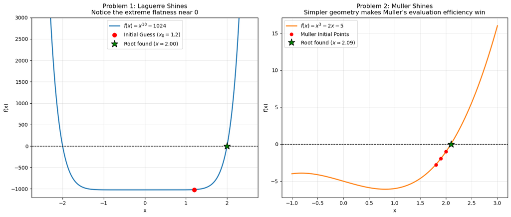

```
Close the plot windows to finish execution.
```

```python
def run_demonstration():
    print("=" * 70)
    print("PROBLEM 1: LAGUERRE SHINES (Distant Guess on High Degree)")
    print("Equation: x^10 - 1024 = 0")
    print("Initial Guess: x0 = 1.2")
    print("-" * 70)
    print("Why? Laguerre's formulation guarantees convergence for polynomials ")
    print("and zooms toward roots. Muller's method gets 'blinded' by the ")
    print("extremely flat geometry of x^10 near zero and takes many steps.")

    # Setup P1
    p1_f = lambda x: x**10 - 1024.0
    p1_df = lambda x: 10 * x**9
    p1_ddf = lambda x: 90 * x**8
    p1_n = 10

    # Laguerre run
    x_lag, iter_lag, eval_lag = laguerre_method(p1_f, p1_df, p1_ddf, p1_n, 1.2 + 0j)

    # Muller run (needs 3 points, we bracket around 1.2)
    x_mul, iter_mul, eval_mul = muller_method(p1_f, 1.0 + 0j, 1.1 + 0j, 1.2 + 0j)

    print(f"\nLaguerre: Root found at {x_lag:.4f}")
    print(
        f"          Iterations: {iter_lag}  |  Total Function/Deriv Evals: {eval_lag}"
    )

    print(f"\nMuller:   Root found at {x_mul:.4f}")
    print(f"          Iterations: {iter_mul} |  Total Function Evals: {eval_mul}")

    print("\n" + "=" * 70)
    print("PROBLEM 2: MULLER SHINES (Evaluation Efficiency)")
    print("Equation: x^3 - 2x - 5 = 0")
    print("Initial Guess: x0 = 2.0")
    print("-" * 70)
    print("Why? Laguerre takes fewer iterations, but it forces us to compute")
    print("f(x), f'(x), and f''(x) EVERY step. Muller only evaluates f(x).")
    print("Muller finds the root with fewer total computational evaluations!")

    # Setup P2
    p2_f = lambda x: x**3 - 2 * x - 5.0
    p2_df = lambda x: 3 * x**2 - 2.0
    p2_ddf = lambda x: 6 * x
    p2_n = 3

    # Laguerre run
    x_lag2, iter_lag2, eval_lag2 = laguerre_method(p2_f, p2_df, p2_ddf, p2_n, 2.0 + 0j)

    # Muller run (bracket around 2.0)
    x_mul2, iter_mul2, eval_mul2 = muller_method(p2_f, 1.8 + 0j, 1.9 + 0j, 2.0 + 0j)

    print(f"\nLaguerre: Root found at {x_lag2:.4f}")
    print(
        f"          Iterations: {iter_lag2}   |  Total Function/Deriv Evals: {eval_lag2}"
    )

    print(f"\nMuller:   Root found at {x_mul2:.4f}")
    print(f"          Iterations: {iter_mul2}   |  Total Function Evals: {eval_mul2}")
    print("=" * 70)

    # -----------------------------------------------------------------
    # Visualizations
    # -----------------------------------------------------------------
    print("\nGenerating visualizations...")
    fig, (ax1, ax2) = plt.subplots(1, 2, figsize=(14, 6))

    # Plot 1: x^10 - 1024
    x1 = np.linspace(-2.5, 2.5, 500)
    # Using .real to safely handle the numpy array without casting complex warnings
    y1 = (x1**10 - 1024.0).real
    ax1.plot(x1, y1, color="#1f77b4", linewidth=2, label="$f(x) = x^{10} - 1024$")
    ax1.axhline(0, color="black", linestyle="--", linewidth=1)
    ax1.plot(1.2, p1_f(1.2).real, "ro", markersize=8, label="Initial Guess ($x_0=1.2$)")
    ax1.plot(
        x_lag.real,
        p1_f(x_lag).real,
        "g*",
        markersize=14,
        markeredgecolor="black",
        label=f"Root found ($x \\approx {x_lag.real:.2f}$)",
    )

    ax1.set_title("Problem 1: Laguerre Shines\nNotice the extreme flatness near 0")
    ax1.set_xlabel("x")
    ax1.set_ylabel("f(x)")
    ax1.set_ylim(-1200, 3000)
    ax1.legend()
    ax1.grid(True, alpha=0.3)

    # Plot 2: x^3 - 2x - 5
    x2 = np.linspace(-1, 3, 500)
    y2 = (x2**3 - 2 * x2 - 5.0).real
    ax2.plot(x2, y2, color="#ff7f0e", linewidth=2, label="$f(x) = x^3 - 2x - 5$")
    ax2.axhline(0, color="black", linestyle="--", linewidth=1)

    # Mark Muller's 3 starting points
    m_pts = [1.8, 1.9, 2.0]
    m_vals = [p2_f(x).real for x in m_pts]
    ax2.plot(m_pts, m_vals, "ro", markersize=6, label="Muller Initial Points")
    ax2.plot(
        x_mul2.real,
        p2_f(x_mul2).real,
        "g*",
        markersize=14,
        markeredgecolor="black",
        label=f"Root found ($x \\approx {x_mul2.real:.2f}$)",
    )

    ax2.set_title(
        "Problem 2: Muller Shines\nSimpler geometry makes Muller's evaluation efficiency win"
    )
    ax2.set_xlabel("x")
    ax2.set_ylabel("f(x)")
    ax2.legend()
    ax2.grid(True, alpha=0.3)

    plt.tight_layout()
    plt.show(block=False)
    print("Close the plot windows to finish execution.")
    plt.show()


if __name__ == "__main__":
    run_demonstration()
```